# Covid Concern exploration

Shira Wild, Maayan Aviram and Noa Radin

Load libraries:

Load the dataset:

```r
covid_concern <- read_rds(here::here("data", "covid_concern.rds"))
sum_covid_cases <- read_rds(here::here("data", "sum_cases.rds"))
```

Let’s take a look at the `covid_concern` dataset

```r
glimpse(covid_concern)
```

```
## Rows: 41
## Columns: 4
## $ Date        <date> 2020-02-25, 2020-02-26, 2020-02-27, 2020-02-28, 2020-02-2~
## $ Democrats   <int> 35, 35, 35, 35, 36, 37, 37, 37, 38, 39, 39, 41, 43, 46, 49~
## $ Republicans <int> -57, -58, -58, -58, -58, -58, -57, -56, -56, -56, -56, -56~
## $ Difference  <int> 92, 93, 93, 93, 94, 95, 94, 93, 94, 95, 95, 97, 97, 97, 97~
```

| Feature | Type | Description |
| --- | --- | --- |
| **Date** | Date | Represent the date that the poll was made |
| **Democrats** | Integer | The average concern level of the democrats (between -100% to 100%) |
| **Republicans** | Integer | The average concern level of the republicans (between -100% to 100%) |
| **Difference** | Integer | The difference between the levels of concern between the democrats and the republicans |

Let’s see some statistics of the dataset

```r
names_vector<-c("Min","Max","Mean","Median","SD")
Democrats<-c(min(covid_concern$Democrats,na.rm = TRUE),max(covid_concern$Democrats,na.rm = TRUE),mean(covid_concern$Democrats,na.rm = TRUE),median(covid_concern$Democrats,na.rm = TRUE),sd(covid_concern$Democrats,na.rm = TRUE))
Republicans<-c(min(covid_concern$Republicans,na.rm = TRUE),max(covid_concern$Republicans,na.rm = TRUE),mean(covid_concern$Republicans,na.rm = TRUE),median(covid_concern$Republicans,na.rm = TRUE),sd(covid_concern$Republicans,na.rm = TRUE))
Difference<-c(min(covid_concern$Difference,na.rm = TRUE),max(covid_concern$Difference,na.rm = TRUE),mean(covid_concern$Difference,na.rm = TRUE),median(covid_concern$Difference,na.rm = TRUE),sd(covid_concern$Difference,na.rm = TRUE))
data_matrix<-rbind(Democrats,Republicans,Difference)
colnames(data_matrix)<-names_vector
data_matrix
```

```
##             Min Max      Mean Median       SD
## Democrats    35  82  60.29268     66 18.05304
## Republicans -58  23 -20.85366    -21 31.49648
## Difference   59  97  81.14634     87 14.17844
```

We can see that the differences between the republicans and the democrats are high at all the edges and parameters. The democrats always have higher concern levels.

Now, visualize:

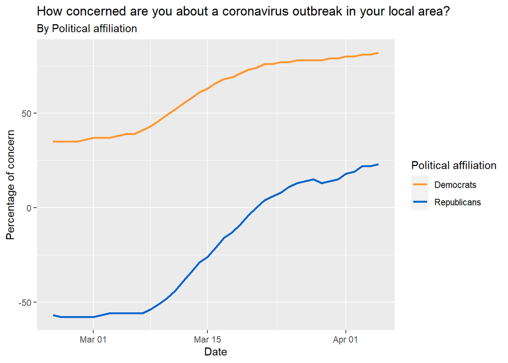

```r
colors <- c("Democrats" = "#ff9933", "Republicans" = "#0066cc")
ggplot(data = covid_concern, mapping = aes(x=Date)) +
  geom_line(aes(y=Democrats,color="Democrats"),size=1)+
  geom_line(aes(y=Republicans,color="Republicans"),size=1)+
   labs(title = "How concerned are you about a coronavirus outbreak in your local area?",subtitle="By Political affiliation " ,x= "Date", y = "Percentage of concern",color = "Political affiliation")+
  scale_color_manual(values = colors)
```

Join the `covid_concern` with the `sum_covid_cases`:

```r
concern_sum <- covid_concern %>%
  inner_join(sum_covid_cases, by = c("Date"))

# Pivot the "concern_sum" by Political affiliation
concern_sum_pivot <- concern_sum %>%
   pivot_longer(cols = c("Democrats","Republicans") , names_to = "Political_affiliation", values_to = "Percentage_of_concern")
head(concern_sum_pivot)
```

```
## # A tibble: 6 x 11
##   Date       Difference Daily_confirmed Total_confirmed Daily_deaths
##   <date>          <int>           <dbl>           <dbl>        <dbl>
## 1 2020-02-25         92               0              14            0
## 2 2020-02-25         92               0              14            0
## 3 2020-02-26         93               1              15            0
## 4 2020-02-26         93               1              15            0
## 5 2020-02-27         93               0              15            0
## 6 2020-02-27         93               0              15            0
## # ... with 6 more variables: Total_deaths <dbl>, Daily_recovered <dbl>,
## #   Total_recovered <dbl>, Active <dbl>, Political_affiliation <chr>,
## #   Percentage_of_concern <int>
```

Now we will show some graphs of the `covid_concern`, combined with `sum_covid_cases`.

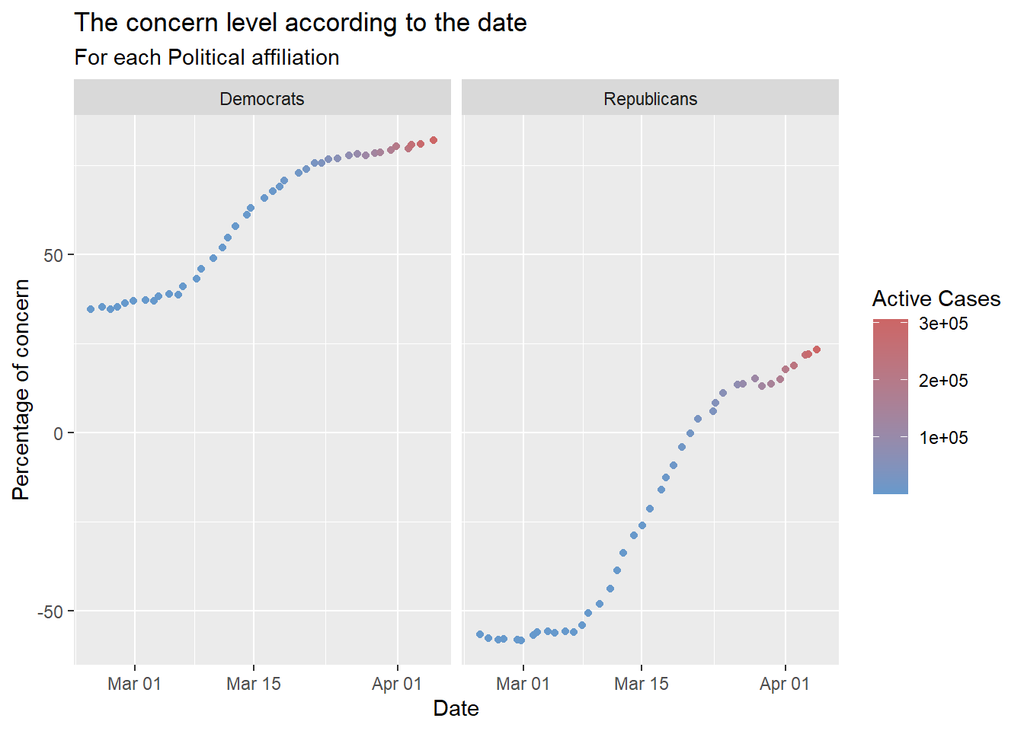

```r
ggplot(data = concern_sum_pivot, mapping = aes(x=Date,y=Percentage_of_concern)) +
  geom_jitter(aes(color=Active)) +
  facet_grid(.~Political_affiliation)+
  scale_color_continuous(low = "#6699cc", high = "#CC6666")+
  labs(y = "Percentage of concern", title = "The concern level according to the date", subtitle= "For each Political affiliation", color = "Active Cases")
```

In this graph we can see that the concern among the American people is rising as the pandemic spreads with the time. The color indicates the amount of active cases for each day.

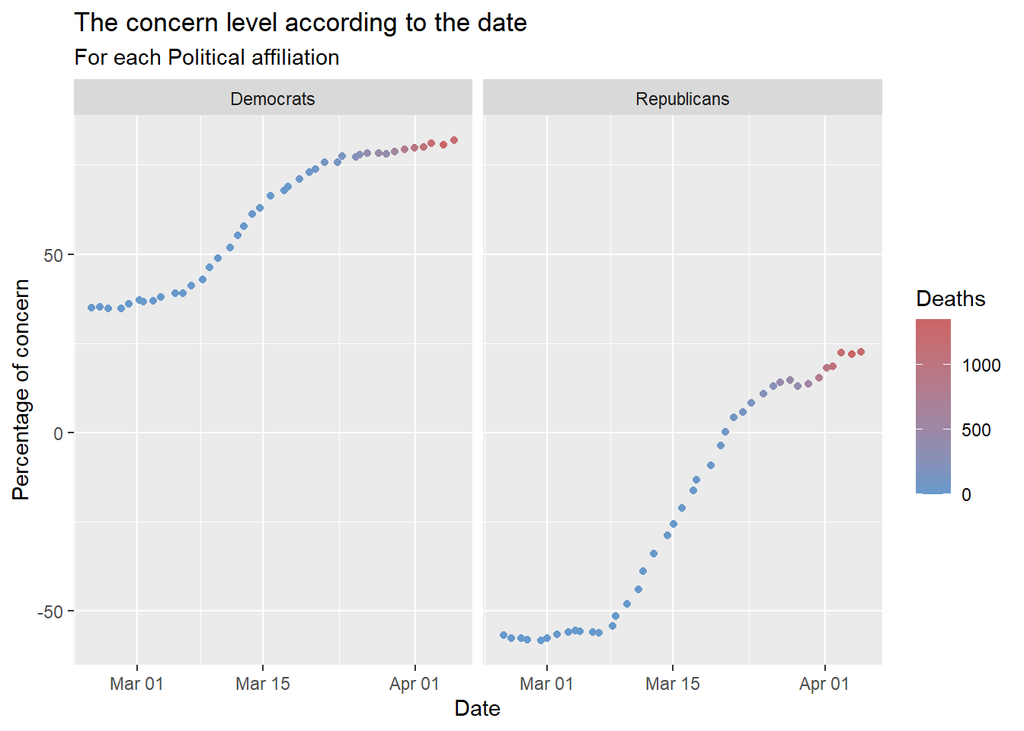

```r
ggplot(data = concern_sum_pivot, mapping = aes(x=Date,y=Percentage_of_concern)) +
  geom_jitter(aes(color=Daily_deaths)) +
  facet_grid(.~Political_affiliation)+
  scale_color_continuous(low = "#6699cc", high = "#CC6666")+
  labs(y = "Percentage of concern", title = "The concern level according to the date", subtitle= "For each Political affiliation", color = "Deaths")
```

In this graph we can see that the concern among the American people is rising as the amount of dead people in a day rises with the time. The color indicates the amount of new deaths for each day.

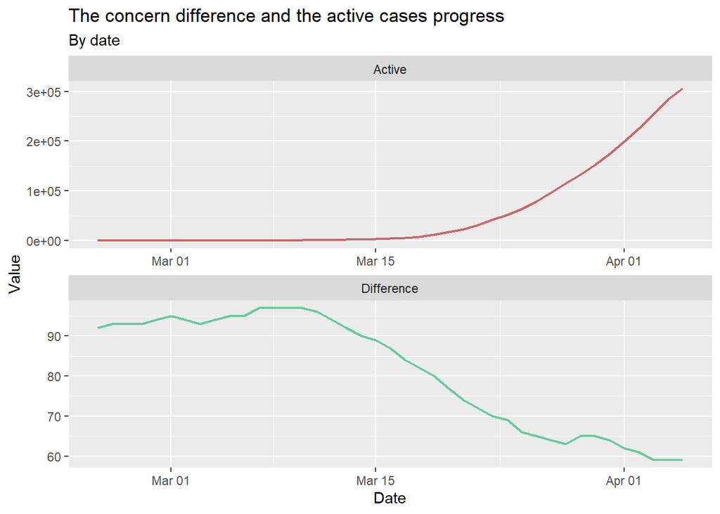

```r
active_diff <- concern_sum%>%
   pivot_longer(cols = c("Active","Difference") , names_to = "Active_Difference", values_to = "Value")

ggplot(data = active_diff, mapping = aes(x=Date,y=Value,color = Active_Difference)) +
  geom_line(size=0.8)+
  facet_wrap(.~Active_Difference ,scales = "free", nrow=2)+
  scale_color_manual(values=c("#CC6666", "#66CC99"))+
  theme(legend.position = "none")+
  labs(title = "The concern difference and the active cases progress", subtitle = "By date", position = "none")
```

We can clearly see that the as the Active cases of covid in each day rises, the difference between the concern level between the republicans and the democrats reduces. That can result from the reason that as the pandemic has been spread, people realized it’s real and dangerous, and the political opinion between the groups got closer.